# Coursera Practical Machine Learning Project

### Background

Using devices such as Jawbone Up, Nike FuelBand, and Fitbit it is now possible to collect a large amount of data about personal activity relatively inexpensively. These type of devices are part of the quantified self movement - a group of enthusiasts who take measurements about themselves regularly to improve their health, to find patterns in their behavior, or because they are tech geeks. One thing that people regularly do is quantify how much of a particular activity they do, but they rarely quantify how well they do it. In this project, your goal will be to use data from accelerometers on the belt, forearm, arm, and dumbell of 6 participants. They were asked to perform barbell lifts correctly and incorrectly in 5 different ways. More information is available from the website here: http://groupware.les.inf.puc-rio.br/har (see the section on the Weight Lifting Exercise Dataset).

### Data

The training data for this project are available here: https://d396qusza40orc.cloudfront.net/predmachlearn/pml-training.csv

The test data are available here: https://d396qusza40orc.cloudfront.net/predmachlearn/pml-testing.csv

The data for this project come from this source: http://groupware.les.inf.puc-rio.br/har. If you use the document you create for this class for any purpose please cite them as they have been very generous in allowing their data to be used for this kind of assignment.

### Goal

The goal of your project is to predict the manner in which they did the exercise. This is the “classe” variable in the training set. You may use any of the other variables to predict with. You should create a report describing how you built your model, how you used cross validation, what you think the expected out of sample error is, and why you made the choices you did. You will also use your prediction model to predict 20 different test cases.

# Data importing and processing

### Preparation

First we clean the environment and remove all old objects:

```r
rm(list=ls())
```

The following R libraries are needed for the project:

(In case these packages are not installed yet, use command install.packages(pkgs))

```r
library(caret);
library(rpart);
library(rpart.plot);
library(randomForest);
library(repmis);

library(rattle);
library(RColorBrewer);
library(knitr);
library(corrplot);
```

We produce random values and ensure reproducibility:

```r
set.seed(12345)
```

### Loading the data set

```r
trainUrl <- "http://d396qusza40orc.cloudfront.net/predmachlearn/pml-training.csv"
testUrl <- "http://d396qusza40orc.cloudfront.net/predmachlearn/pml-testing.csv"

training <- read.csv(url(trainUrl), na.strings=c("NA","#DIV/0!",""))
testing <- read.csv(url(testUrl), na.strings=c("NA","#DIV/0!",""))
```

Partition the data set into a training set for prediction (70%) and a validation set to compute the out-of-sample errors (30%):

```r
inTrain <- createDataPartition(training$classe, p=0.7, list=FALSE)
TrainingSet <- training[inTrain, ]
TestingSet <- training[-inTrain, ]
dim(TrainingSet)
```

```
## [1] 13737   160
```

```r
dim(TestingSet)
```

```
## [1] 5885  160
```

### Cleaning the data set

Remove all Near Zero variance variables:

```r
NZV <- nearZeroVar(TrainingSet)
TrainingSet <- TrainingSet[, -NZV]
TestingSet  <- TestingSet[, -NZV]
dim(TrainingSet)
```

```
## [1] 13737   130
```

```r
dim(TestingSet)
```

```
## [1] 5885  130
```

Remove all varibales with plenty of NA (85%):

```r
NA_var <- sapply(TrainingSet, function(x) mean(is.na(x))) > 0.85
TrainingSet <- TrainingSet[, NA_var==FALSE]
TestingSet  <- TestingSet[, NA_var==FALSE]
dim(TrainingSet)
```

```
## [1] 13737    59
```

```r
dim(TestingSet)
```

```
## [1] 5885   59
```

# Prediction

We will use the following two methods for prediction:

1. Random forest
2. Decision Tree

## 1. Random forest

We will consider a 5-fold cross validation here:

```r
control_RF <- trainControl(method="cv", number=5, verboseIter=FALSE)
method_RF <- train(classe ~ ., data=TrainingSet, method="rf",
                          trControl=control_RF)
method_RF$finalModel
```

```
##
## Call:
##  randomForest(x = x, y = y, mtry = param$mtry)
##                Type of random forest: classification
##                      Number of trees: 500
## No. of variables tried at each split: 41
##
##         OOB estimate of  error rate: 0.01%
## Confusion matrix:
##      A    B    C    D    E  class.error
## A 3906    0    0    0    0 0.0000000000
## B    1 2657    0    0    0 0.0003762227
## C    0    0 2396    0    0 0.0000000000
## D    0    0    0 2252    0 0.0000000000
## E    0    0    0    0 2525 0.0000000000
```

Prediction on test data set:

```r
predict_RF <- predict(method_RF, newdata=TestingSet)
confMat_RF <- confusionMatrix(predict_RF, TestingSet$classe)
confMat_RF
```

```
## Confusion Matrix and Statistics
##
##           Reference
## Prediction    A    B    C    D    E
##          A 1674    0    0    0    0
##          B    0 1138    0    0    0
##          C    0    1 1026    0    0
##          D    0    0    0  964    0
##          E    0    0    0    0 1082
##
## Overall Statistics
##
##                Accuracy : 0.9998
##                  95% CI : (0.9991, 1)
##     No Information Rate : 0.2845
##     P-Value [Acc > NIR] : < 2.2e-16
##
##                   Kappa : 0.9998
##  Mcnemar's Test P-Value : NA
##
## Statistics by Class:
##
##                      Class: A Class: B Class: C Class: D Class: E
## Sensitivity            1.0000   0.9991   1.0000   1.0000   1.0000
## Specificity            1.0000   1.0000   0.9998   1.0000   1.0000
## Pos Pred Value         1.0000   1.0000   0.9990   1.0000   1.0000
## Neg Pred Value         1.0000   0.9998   1.0000   1.0000   1.0000
## Prevalence             0.2845   0.1935   0.1743   0.1638   0.1839
## Detection Rate         0.2845   0.1934   0.1743   0.1638   0.1839
## Detection Prevalence   0.2845   0.1934   0.1745   0.1638   0.1839
## Balanced Accuracy      1.0000   0.9996   0.9999   1.0000   1.0000
```

Visualize results:

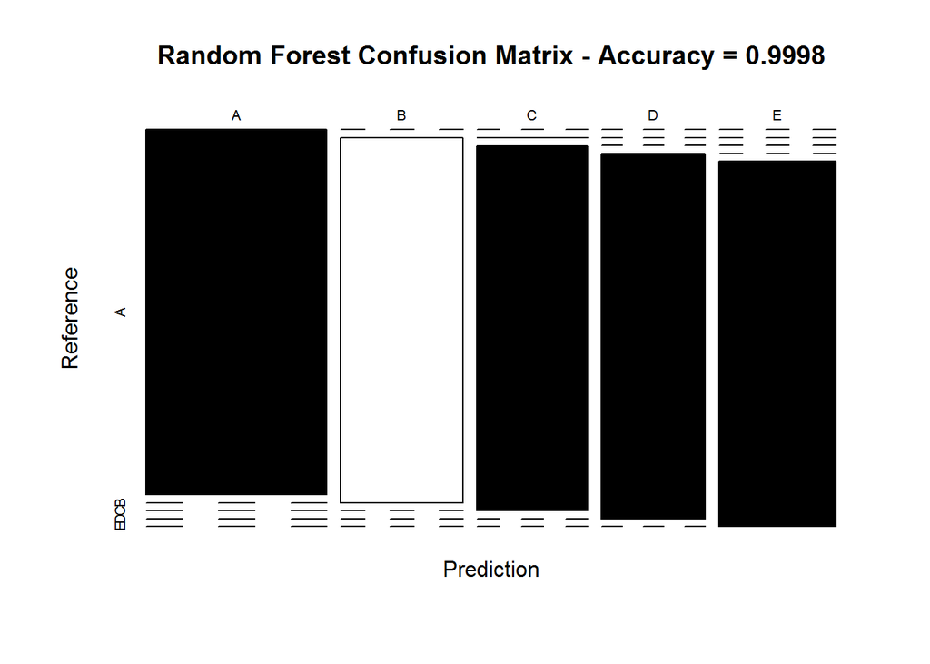

```r
plot(confMat_RF$table, col = confMat_RF$byClass,
     main = paste("Random Forest Confusion Matrix - Accuracy =",
                  round(confMat_RF$overall['Accuracy'], 4)))
```

## 2. Decision Trees

[figure not shown]

```r
method_DT <- rpart(classe ~ ., data=TrainingSet, method="class")
fancyRpartPlot(method_DT)
```

Prediction on test data set:

```r
predict_DT <- predict(method_DT, newdata=TestingSet, type="class")
confMat_DT <- confusionMatrix(predict_DT, TestingSet$classe)
confMat_DT
```

```
## Confusion Matrix and Statistics
##
##           Reference
## Prediction    A    B    C    D    E
##          A 1673    0    0    0    0
##          B    1 1138    0    0    0
##          C    0    1 1026    1    0
##          D    0    0    0  963    0
##          E    0    0    0    0 1082
##
## Overall Statistics
##
##                Accuracy : 0.9995
##                  95% CI : (0.9985, 0.9999)
##     No Information Rate : 0.2845
##     P-Value [Acc > NIR] : < 2.2e-16
##
##                   Kappa : 0.9994
##  Mcnemar's Test P-Value : NA
##
## Statistics by Class:
##
##                      Class: A Class: B Class: C Class: D Class: E
## Sensitivity            0.9994   0.9991   1.0000   0.9990   1.0000
## Specificity            1.0000   0.9998   0.9996   1.0000   1.0000
## Pos Pred Value         1.0000   0.9991   0.9981   1.0000   1.0000
## Neg Pred Value         0.9998   0.9998   1.0000   0.9998   1.0000
## Prevalence             0.2845   0.1935   0.1743   0.1638   0.1839
## Detection Rate         0.2843   0.1934   0.1743   0.1636   0.1839
## Detection Prevalence   0.2843   0.1935   0.1747   0.1636   0.1839
## Balanced Accuracy      0.9997   0.9995   0.9998   0.9995   1.0000
```

Visualize results:

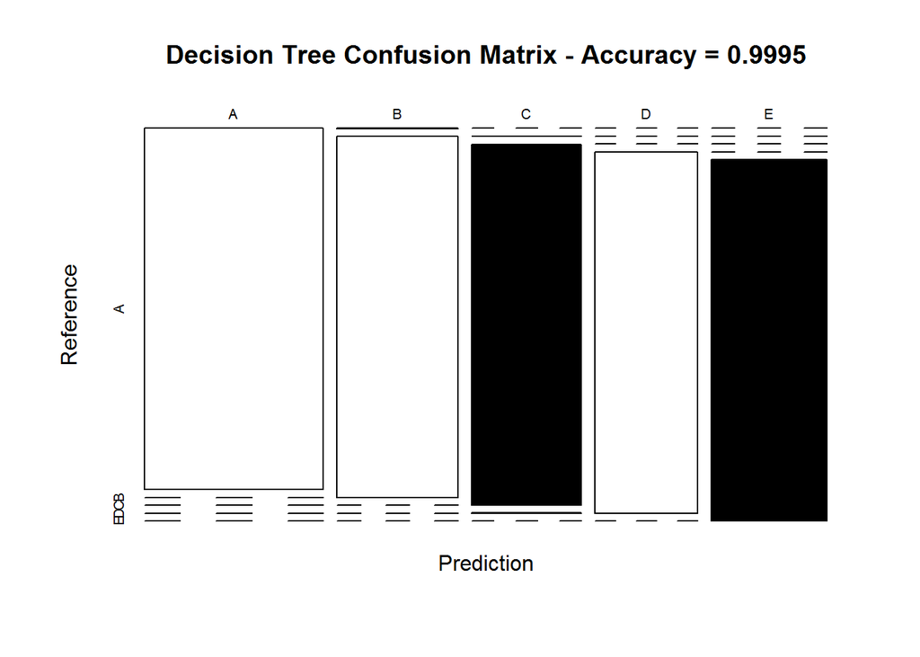

```r
plot(confMat_DT$table, col = confMat_DT$byClass,
     main = paste("Decision Tree Confusion Matrix - Accuracy =",
                  round(confMat_DT$overall['Accuracy'], 4)))
```

# Applying predicting results to the test data set

In this case the Random Forest model will be applied to predict the 20 quiz results.

```r
predict(method_RF, testing)
```

[output not shown]

# 08_Practical_Machine_Learning